# ClickThroughAnalysis

## Import Libraries

```r
library(caTools)
library(rpart)
library(rpart.plot)
library(caret)
library(e1071)
library(xgboost)
library(Matrix)
library(randomForest)
library(MLmetrics)
```

## Import datasets

Import dataset

```r
train <- read.csv("content_train.tsv",sep = '\t')
```

## Data Cleaning

We are using only `content1`

```
##   customer.id       content_1       express.no.transactions
##  Min.   :     3   Min.   :0.00000   Min.   :  0.00
##  1st Qu.: 25070   1st Qu.:0.00000   1st Qu.: 37.00
##  Median : 50027   Median :0.00000   Median : 50.00
##  Mean   : 50056   Mean   :0.01091   Mean   : 50.03
##  3rd Qu.: 75048   3rd Qu.:0.00000   3rd Qu.: 63.00
##  Max.   :100000   Max.   :1.00000   Max.   :139.00
##
##  express.total.spend metro.no.transactions metro.total.spend
##  Min.   :    0.0     Min.   :  0.00        Min.   :    0.0
##  1st Qu.:  208.8     1st Qu.: 37.00        1st Qu.:  308.0
##  Median :  490.9     Median : 50.00        Median :  733.9
##  Mean   :  767.4     Mean   : 50.07        Mean   : 1159.7
##  3rd Qu.: 1004.7     3rd Qu.: 63.00        3rd Qu.: 1496.7
##  Max.   :19714.0     Max.   :140.00        Max.   :21864.8
##
##  superstore.no.transactions superstore.total.spend extra.no.transactions
##  Min.   :  0.00             Min.   :    0.0        Min.   :  0.00
##  1st Qu.: 37.00             1st Qu.:  762.7        1st Qu.: 37.00
##  Median : 50.00             Median : 1801.9        Median : 50.00
##  Mean   : 50.01             Mean   : 2824.6        Mean   : 49.81
##  3rd Qu.: 63.00             3rd Qu.: 3662.4        3rd Qu.: 63.00
##  Max.   :133.00             Max.   :73988.5        Max.   :129.00
##
##  extra.total.spend fandf.no.transactions fandf.total.spend
##  Min.   :    0.0   Min.   :  0.00        Min.   :    0.0
##  1st Qu.:  764.5   1st Qu.: 17.00        1st Qu.:  191.2
##  Median : 1788.5   Median : 30.00        Median :  588.0
##  Mean   : 2836.8   Mean   : 30.51        Mean   : 1040.9
##  3rd Qu.: 3679.3   3rd Qu.: 43.00        3rd Qu.: 1350.4
##  Max.   :82972.7   Max.   :109.00        Max.   :40018.3
##
##  petrol.no.transactions petrol.total.spend direct.no.transactions
##  Min.   :  0.00         Min.   :    0.0    Min.   :  0.0
##  1st Qu.: 17.00         1st Qu.:  105.5    1st Qu.: 17.0
##  Median : 30.00         Median :  320.1    Median : 30.0
##  Mean   : 30.45         Mean   :  572.9    Mean   : 30.5
##  3rd Qu.: 43.00         3rd Qu.:  737.2    3rd Qu.: 43.0
##  Max.   :101.00         Max.   :13510.1    Max.   :113.0
##
##  direct.total.spend    gender          affluency
##  Min.   :    0.0    Female:22830   High     : 9232
##  1st Qu.:  513.1    Male  :23192   Low      : 9275
##  Median : 1572.7                   Mid      :22875
##  Mean   : 2827.9                   Very High: 2261
##  3rd Qu.: 3677.5                   Very Low : 2379
##  Max.   :76195.4
##
##                 county
##  Greater London    : 6940
##  West Midlands     : 2334
##  Greater Manchester: 2284
##  West Yorkshire    : 1994
##  Essex             : 1259
##  Kent              : 1228
##  (Other)           :29983
```

### Analysing the dependent variable

```r
table(train_content1$content_1)
```

```
##
##     0     1
## 45520   502
```

#### From express total spend

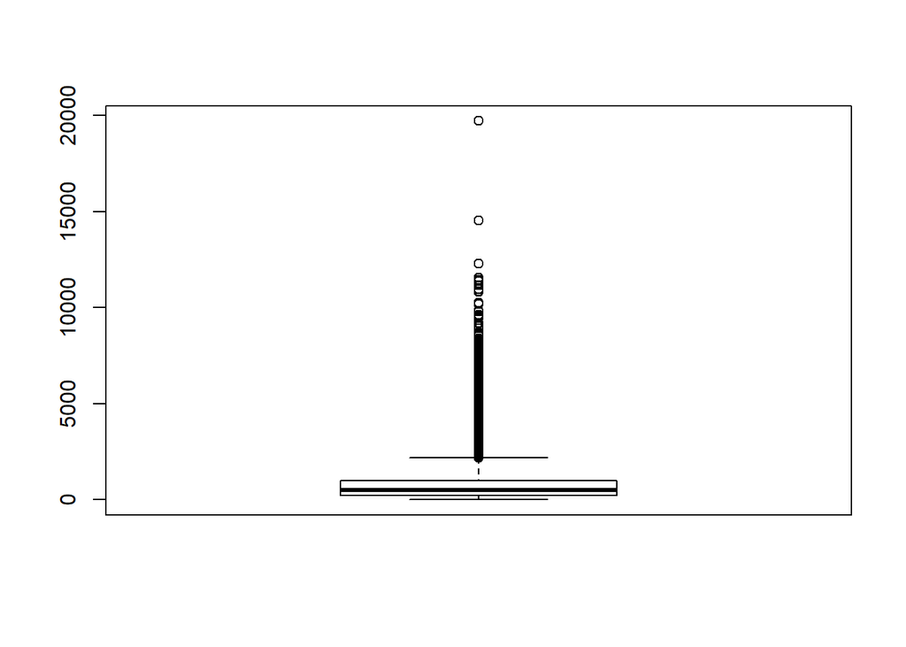

```r
boxplot(train_content1$express.total.spend)
```

```r
outlier <- boxplot.stats(train_content1$express.total.spend)$out
min(train_content1$express.total.spend)
```

```
## [1] 0
```

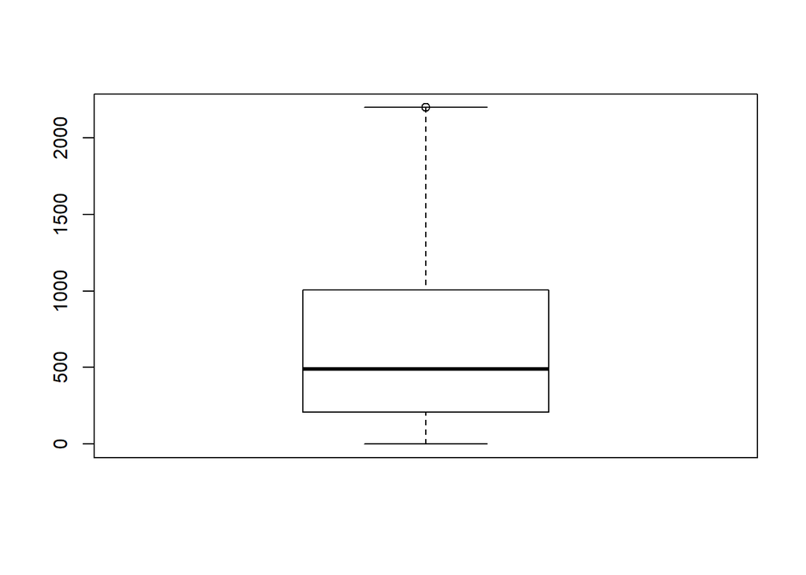

```r
train_content1$express.total.spend[train_content1$express.total.spend >= min(outlier)] <- min(outlier)
#boxplot.stats(train_content1$express.total.spend)$out
boxplot(train_content1$express.total.spend)
```

```r
#train_content1$express.total.spend<-log(train_content1$express.total.spend)
```

From metro total spend

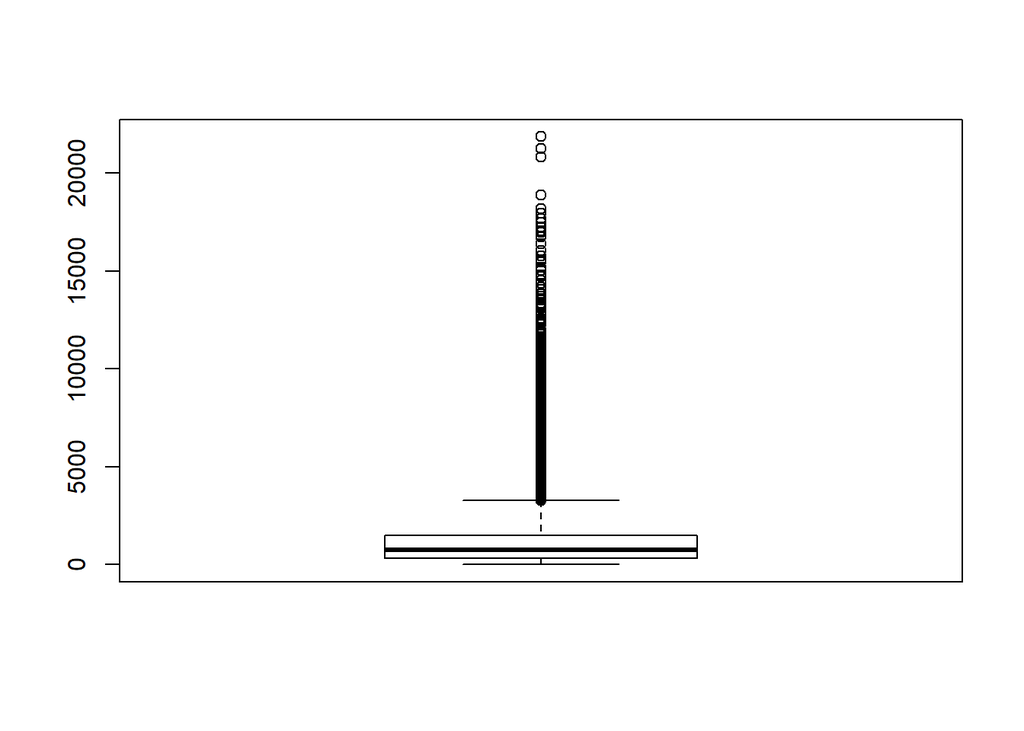

```r
boxplot(train_content1$metro.total.spend)
```

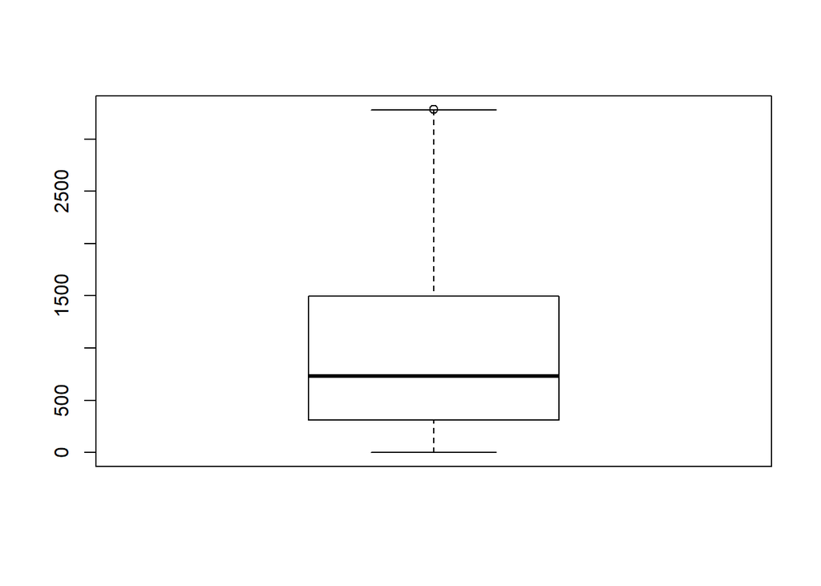

```r
outlier <- boxplot.stats(train_content1$metro.total.spend)$out

train_content1$metro.total.spend[train_content1$metro.total.spend >= min(outlier)] <- min(outlier)
#boxplot.stats(train_content1$metro.total.spend)$out
boxplot(train_content1$metro.total.spend)
```

From `superstore.total.spend`

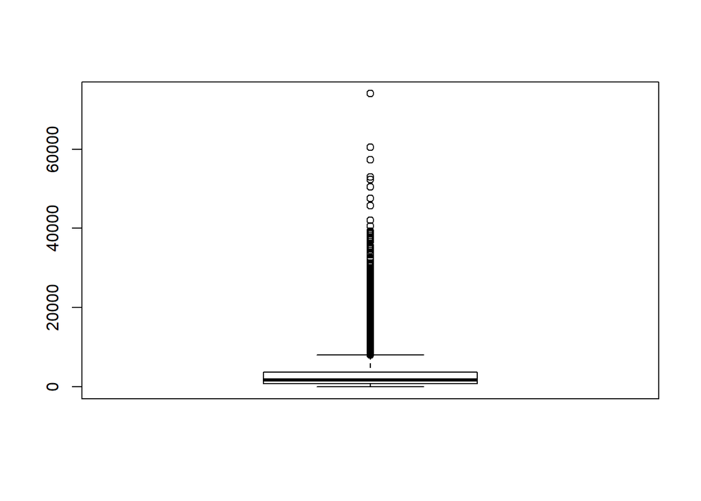

```r
boxplot(train_content1$superstore.total.spend)
```

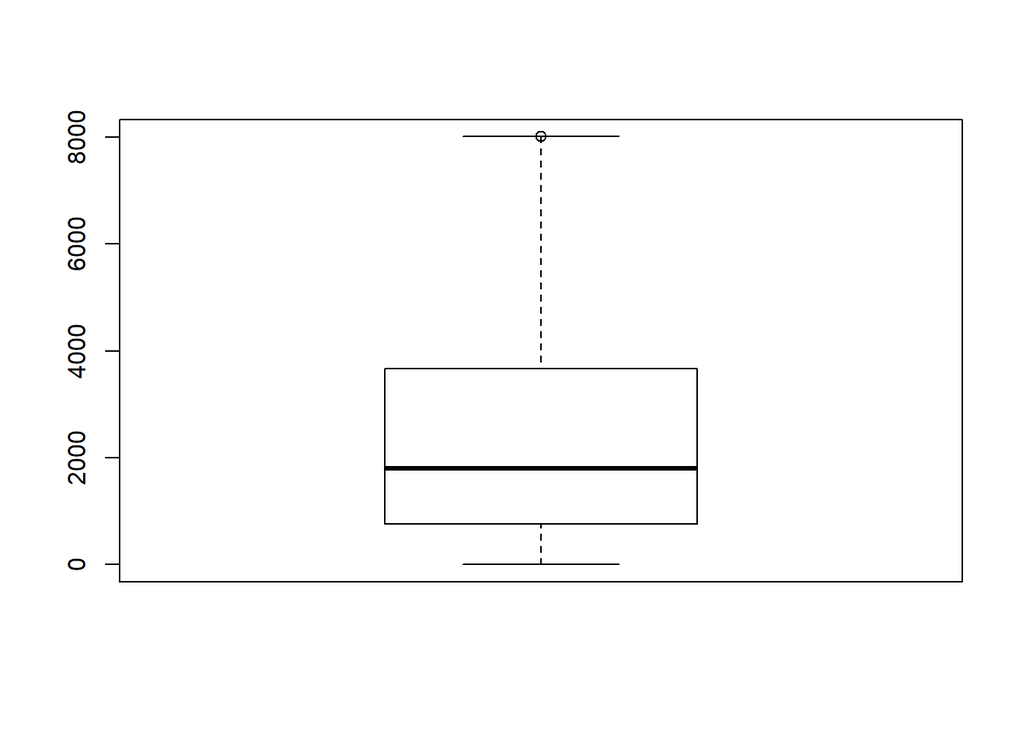

```r
outlier <- boxplot.stats(train_content1$superstore.total.spend)$out

train_content1$superstore.total.spend[train_content1$superstore.total.spend >= min(outlier)] <- min(outlier)
boxplot(train_content1$superstore.total.spend)
```

From `extra.total.spend`

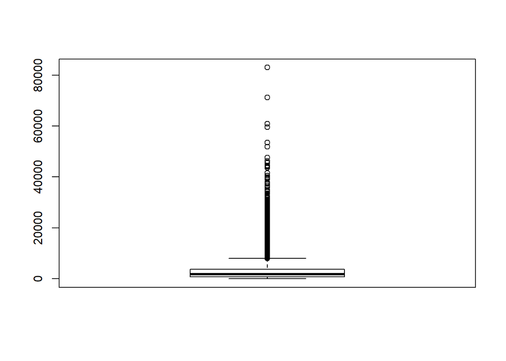

```r
boxplot(train_content1$extra.total.spend)
```

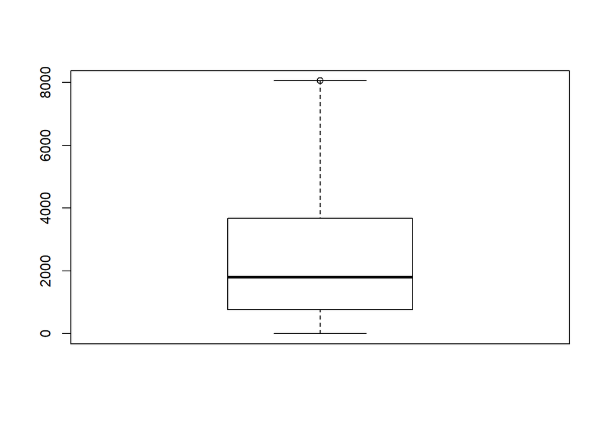

```r
outlier <- boxplot.stats(train_content1$extra.total.spend)$out

train_content1$extra.total.spend[train_content1$extra.total.spend >= min(outlier)] <- min(outlier)
boxplot(train_content1$extra.total.spend)
```

From `fandf.total.spend`

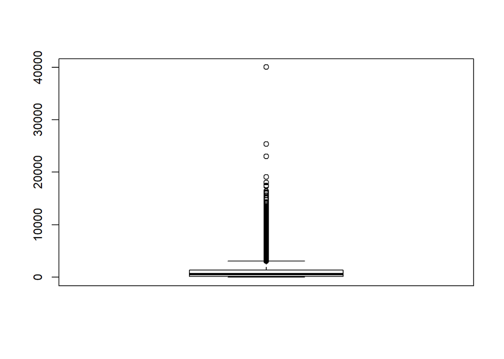

```r
boxplot(train_content1$fandf.total.spend)
```

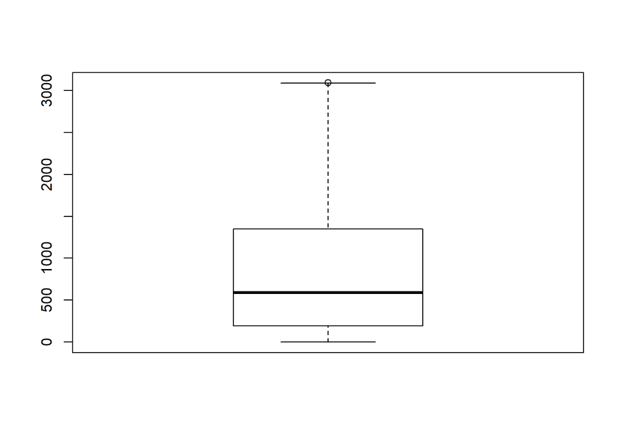

```r
outlier <- boxplot.stats(train_content1$fandf.total.spend)$out
#min(train_content1$fandf.total.spend)
train_content1$fandf.total.spend[train_content1$fandf.total.spend >= min(outlier)] <- min(outlier)
boxplot(train_content1$fandf.total.spend)
```

From `petrol.total.spend`

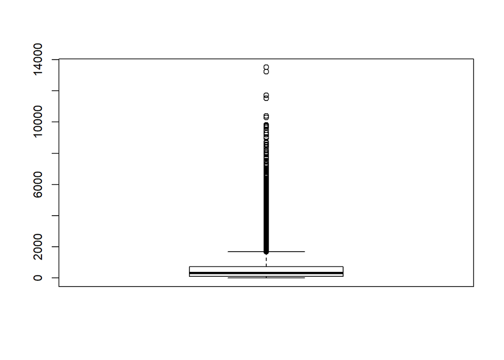

```r
boxplot(train_content1$petrol.total.spend)
```

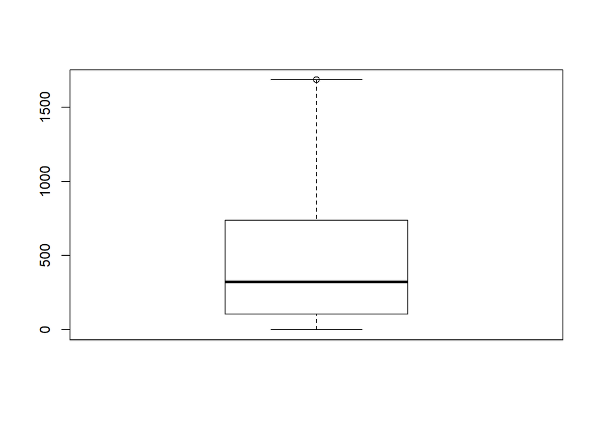

```r
outlier <- boxplot.stats(train_content1$petrol.total.spend)$out
train_content1$petrol.total.spend[train_content1$petrol.total.spend >= min(outlier)] <- min(outlier)
boxplot(train_content1$petrol.total.spend)
```

From `direct.total.spend`

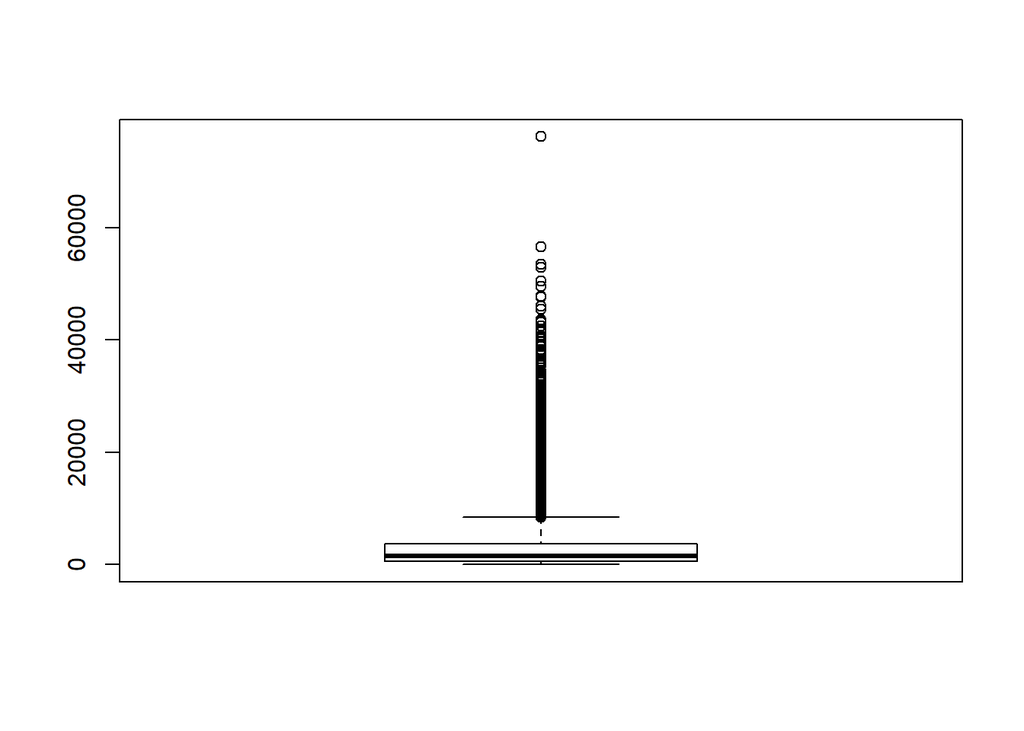

```r
boxplot(train_content1$direct.total.spend)
```

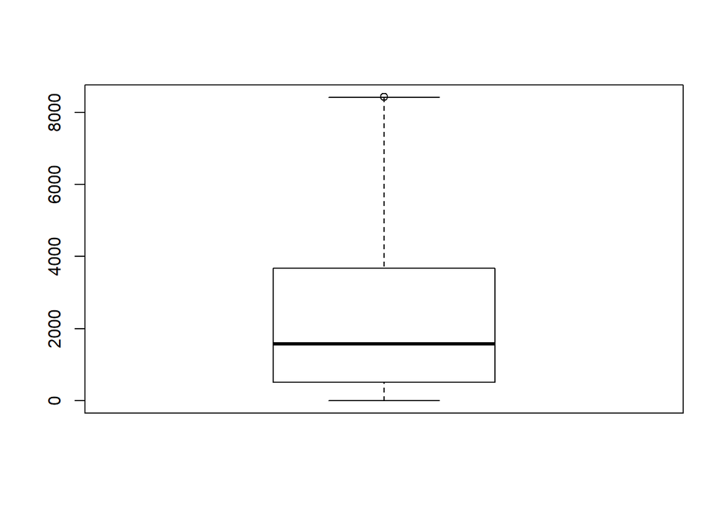

```r
outlier <- boxplot.stats(train_content1$direct.total.spend)$out
#min(train_content1$direct.total.spend)
train_content1$direct.total.spend[train_content1$direct.total.spend >= min(outlier)] <- min(outlier)
boxplot(train_content1$direct.total.spend)
```

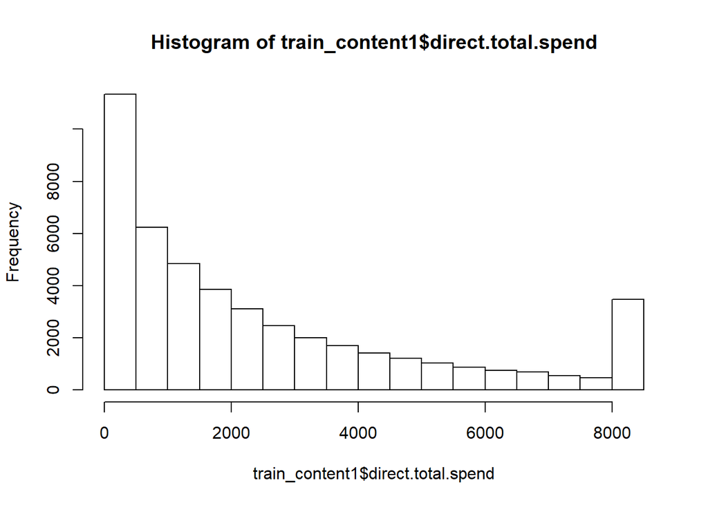

```r
hist(train_content1$direct.total.spend)
```

```r
#train_content1$direct.total.spend<-log(train_content1$direct.total.spend)
```

So far we have removed the outliers from all the spend variables.

```r
set.seed(88)
split <- sample.split(train_content1$content_1,SplitRatio = 0.7)
Train <-subset(train_content1,split==TRUE)
Test <-subset(train_content1,split==FALSE)
#summary(Train)
```

## Model Building

### Build decision tree using rpart.

Since the dataset is highly imbalanced we cannot use the rpart with default parameters. We will be doing cost-sensitive learning We cannot use `classification error` as a performance metric here. We will be using `penalty error` as our performance metric

Penalty Error = sum(Confusion Matrix * Penalty Matrix)/(No. of Observations)

We have to change the loss matrix so that while creating splits, it penalises the errors of both the classes differently.

Creating a penalty matrix that penalises `FN` 91 times more than `FP`. We are keeping the same ratio as we have #Negatives/#Positives

```r
PenaltyMatrix = matrix(data = c(0,1,91,0),nrow = 2,ncol = 2,byrow = T)
```

Applying Decision Tree

```r
train_content1$county<- as.character(train_content1$county)

model<-rpart(content_1~express.no.transactions+express.total.spend+metro.no.transactions+metro.total.spend+superstore.no.transactions+superstore.total.spend+extra.no.transactions+extra.total.spend+fandf.no.transactions+fandf.total.spend+petrol.no.transactions+petrol.total.spend+direct.no.transactions+direct.total.spend+gender+affluency,data=Train,cp=0.001,method='class',parms=list(loss=PenaltyMatrix))

pred_train <- predict(model,type='class')
table(Train$content_1,pred_train)
```

```
##    pred_train
##         0     1
##   0 27114  4750
##   1     0   351
```

The tree works well on the train data, but there is a risk of overfitting as we have used very low value of `cp` complexity parameter.  
We will be doing predictions on the test data to validate our model and calculating the penalty error

```r
pred_test <- predict(model,newdata = Test,type='class')
conf <- as.matrix(table(`Actual` = Test$content_1,'Prediction'=pred_test))
conf
```

```
##       Prediction
## Actual     0     1
##      0 11465  2191
##      1   126    25
```

```r
PenaltyError <- sum(conf*PenaltyMatrix)/nrow(Test)
PenaltyError
```

```
## [1] 0.9891359
```

From the confusion matrix above it is clear that the tree is overfitting and we are not getting the same level of performance.

### Build decission tree using `caret`

We are using caret package to apply cross-validation

```r
numFolds = trainControl(method = "cv",number = 10)

cpGrid <- expand.grid(cp = seq(0.00001,0.001,0.00001))

model_cv<-train(as.factor(content_1)~express.no.transactions+express.total.spend+metro.no.transactions+metro.total.spend+superstore.no.transactions+superstore.total.spend+extra.no.transactions+extra.total.spend+fandf.no.transactions+fandf.total.spend+petrol.no.transactions+petrol.total.spend+direct.no.transactions+direct.total.spend+gender+affluency,data = Train,trControl=numFolds,tuneGrid=cpGrid,method="rpart",maximize=F,metric="Kappa")

pred_train <-predict(model_cv)
table(Train$content_1,pred_train)
```

```
##    pred_train
##         0     1
##   0 31864     0
##   1   351     0
```

```r
pred_test <-predict(model_cv,newdata = Test)
table(Test$content_1,pred_test)
```

```
##    pred_test
##         0     1
##   0 13656     0
##   1   151     0
```

## Build RandomForest

Here we will be downsampling the class `0` to reduce the imbalance

```r
model_rf<-randomForest(as.factor(content_1)~express.no.transactions+express.total.spend+metro.no.transactions+metro.total.spend+superstore.no.transactions+superstore.total.spend+extra.no.transactions+extra.total.spend+fandf.no.transactions+fandf.total.spend+petrol.no.transactions+petrol.total.spend+direct.no.transactions+direct.total.spend+gender+affluency,data=Train,sampsize = c(900,351),strata=Train$content_1,cutoff=c(0.7,0.3))
# Doing prediction on the test data
pred_rf <-predict(model_rf,newdata = Test)
conf_rf <-as.matrix(table(Test$content_1,pred_rf))
conf_rf
```

```
##    pred_rf
##         0     1
##   0 11632  2024
##   1   128    23
```

```r
PenaltyError_rf <- sum(conf_rf*PenaltyMatrix)/nrow(Test)
PenaltyError_rf
```

```
## [1] 0.9902224
```

### Applying Gradient Boosting using `xgboost`

We will be using `scale_pos_weight` argument to balance the data.

Along with that we will be passing a custom evaluation metric in the `feval` argument that calculates the `penalty error` and minimizes it

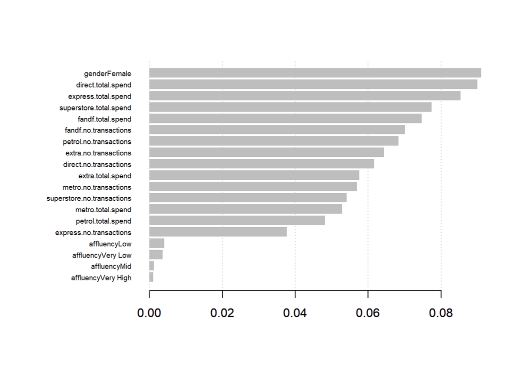

```r
sparse_matrix<-sparse.model.matrix(content_1~.-1-customer.id-county,data = Train)
#sparse_matrix@Dim

dtrain<-xgb.DMatrix(data=sparse_matrix,label=Train$content_1)

sparse_matrix_test<-sparse.model.matrix(content_1~.-1-customer.id-county,data = Test)

dtest<-xgb.DMatrix(data=sparse_matrix_test,label=Test$content_1)

evalerror <- function(preds, dtrain) {
  labels <- getinfo(dtrain, "label")
  B<-matrix(data = rep(0,4),nrow = 2,ncol = 2)
  A<-as.matrix(table(labels,preds>=0.5))
  B[1:nrow(A),1:ncol(A)]<-A
  err<-sum(B*PenaltyMatrix)/nrow(dtrain)
  return(list(metric = "penalty_error", value = err))
}
watchlist=list(train = dtrain, test=dtest)

params=list(eta=0.01,max_depth=8,objective="binary:logistic")

model_xgb<-xgb.train(params = params,data = dtrain,verbose = 0,watchlist = watchlist,nrounds=10000,nthread=8,maximize=F,early_stopping_rounds = 100,scale_pos_weight=91,feval=evalerror)

imp <-xgb.importance(feature_names = colnames(sparse_matrix),model = model_xgb)

xgb.plot.importance(imp)
```

```r
pred_xgb<-predict(model_xgb,newdata = dtest)
table(Test$content_1,pred_xgb>=0.5)
```

```
##
##     FALSE  TRUE
##   0 10072  3584
##   1    89    62
```

We are finalizing with this `xgboost` model. Now we will be doing our prediction on the `content_test.tsv` data.

```r
test <- read.csv("content_test.tsv",sep='\t')
```

### Removing Outliers from test data

#### From express total spend

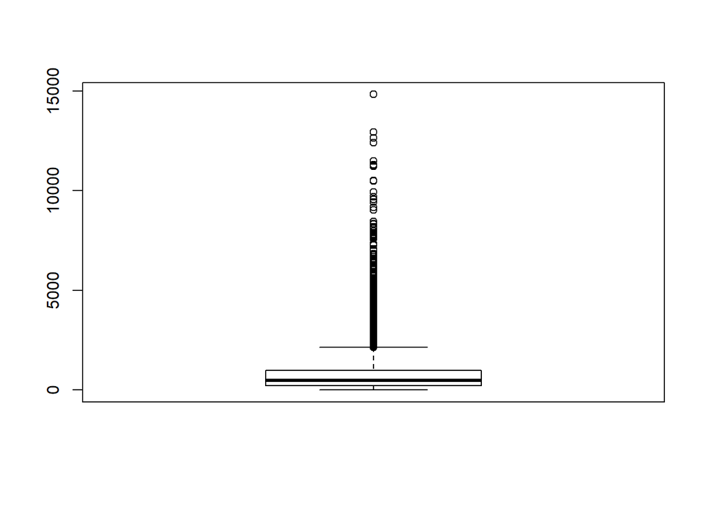

```r
boxplot(test$express.total.spend)
```

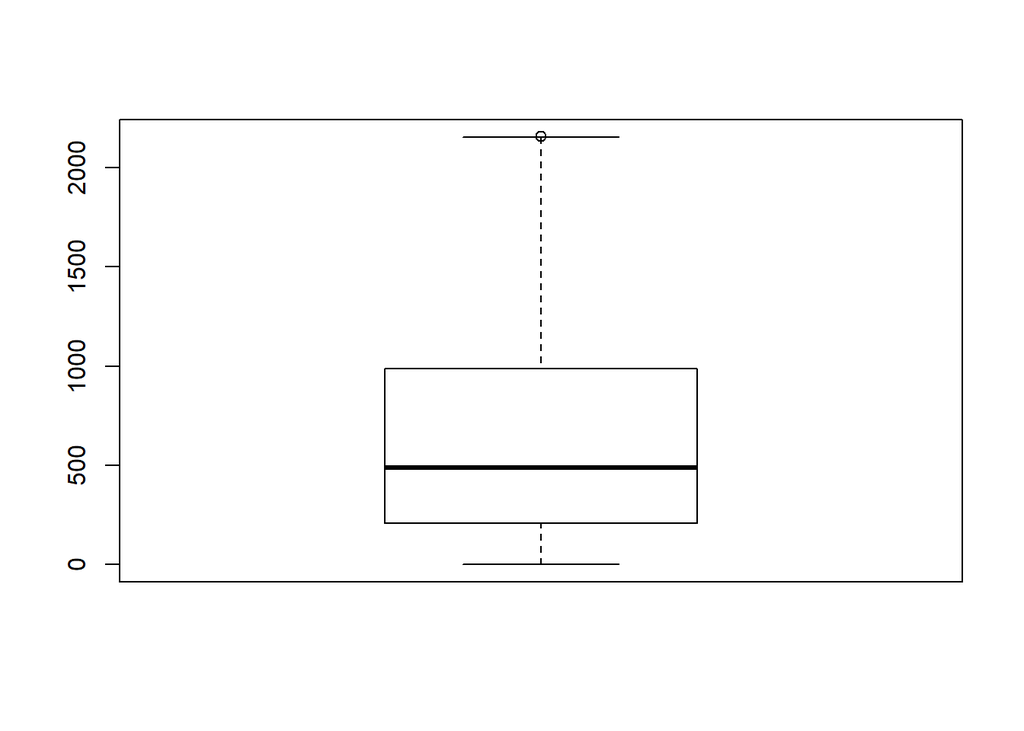

```r
outlier <- boxplot.stats(test$express.total.spend)$out
#min(test$express.total.spend)
test$express.total.spend[test$express.total.spend >= min(outlier)] <- min(outlier)
#boxplot.stats(test$express.total.spend)$out
boxplot(test$express.total.spend)
```

```r
#test$express.total.spend<-log(test$express.total.spend)
```

From metro total spend

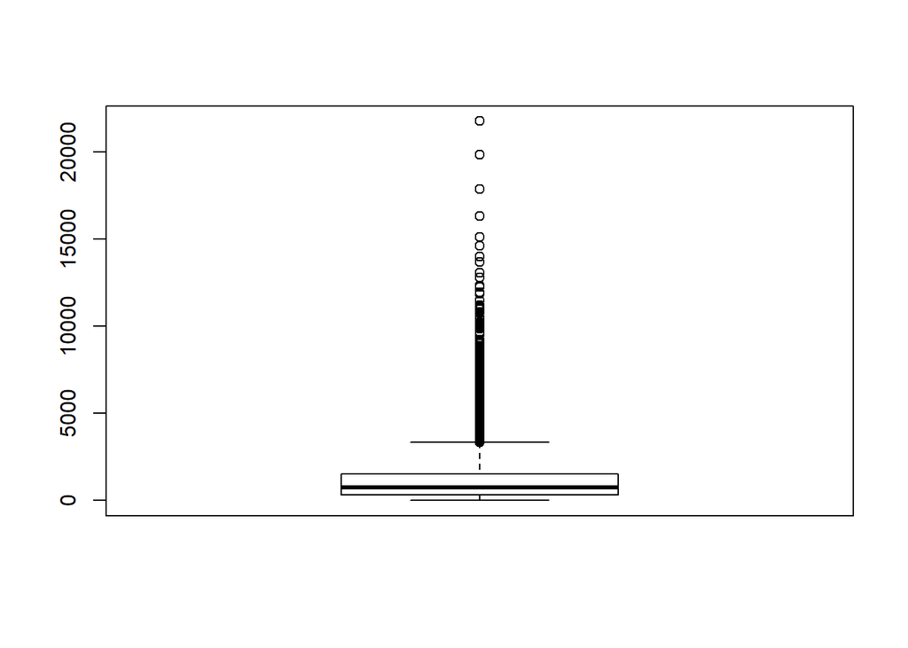

```r
boxplot(test$metro.total.spend)
```

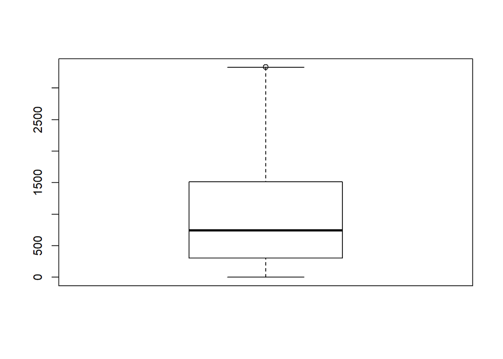

```r
outlier <- boxplot.stats(test$metro.total.spend)$out

test$metro.total.spend[test$metro.total.spend >= min(outlier)] <- min(outlier)
#boxplot.stats(test$metro.total.spend)$out
boxplot(test$metro.total.spend)
```

From `superstore.total.spend`

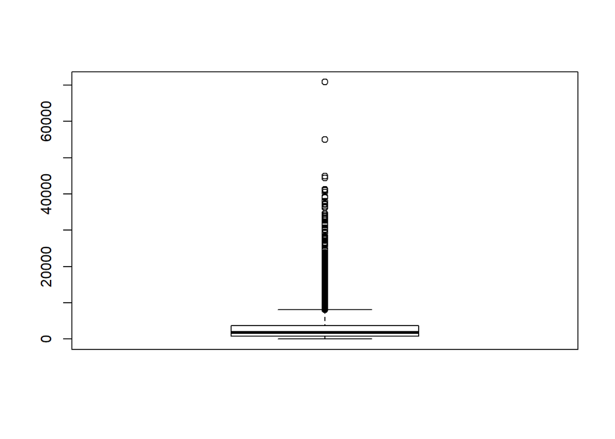

```r
boxplot(test$superstore.total.spend)
```

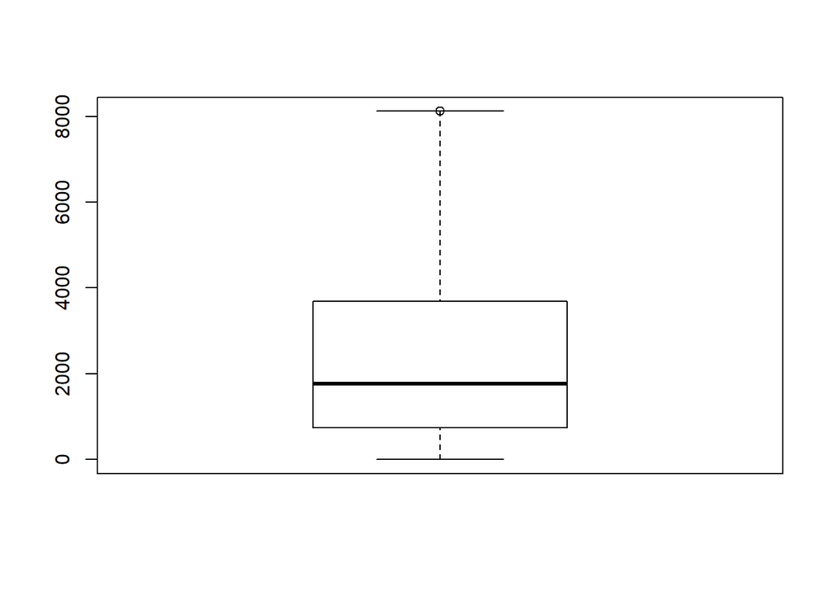

```r
outlier <- boxplot.stats(test$superstore.total.spend)$out

test$superstore.total.spend[test$superstore.total.spend >= min(outlier)] <- min(outlier)
boxplot(test$superstore.total.spend)
```

From `extra.total.spend`

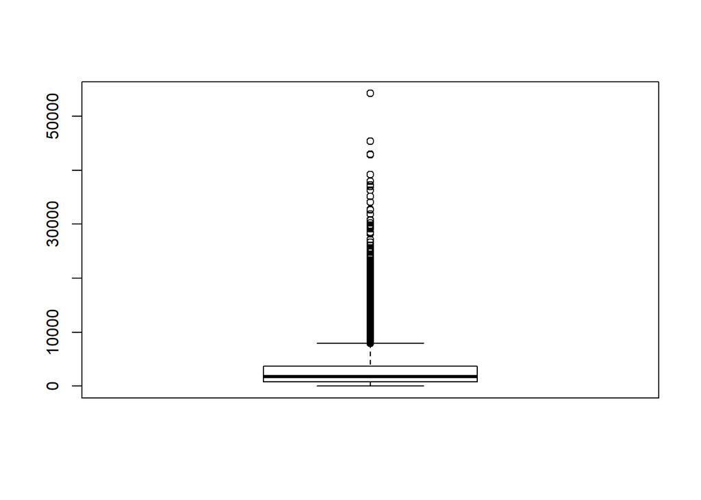

```r
boxplot(test$extra.total.spend)
```

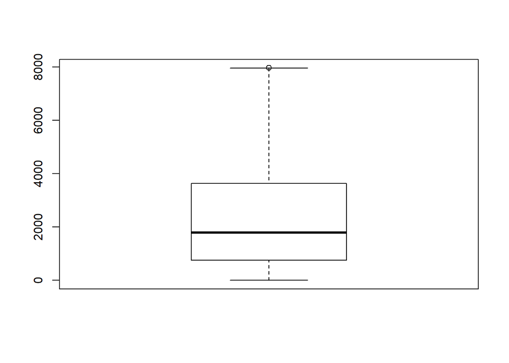

```r
outlier <- boxplot.stats(test$extra.total.spend)$out

test$extra.total.spend[test$extra.total.spend >= min(outlier)] <- min(outlier)
boxplot(test$extra.total.spend)
```

From `fandf.total.spend`

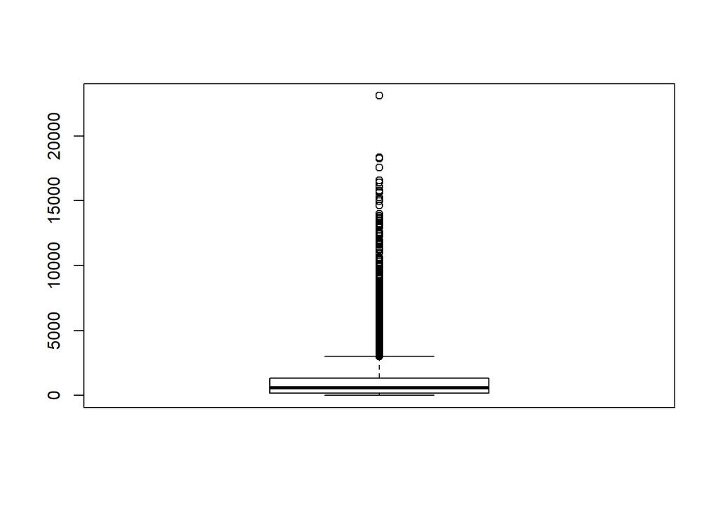

```r
boxplot(test$fandf.total.spend)
```

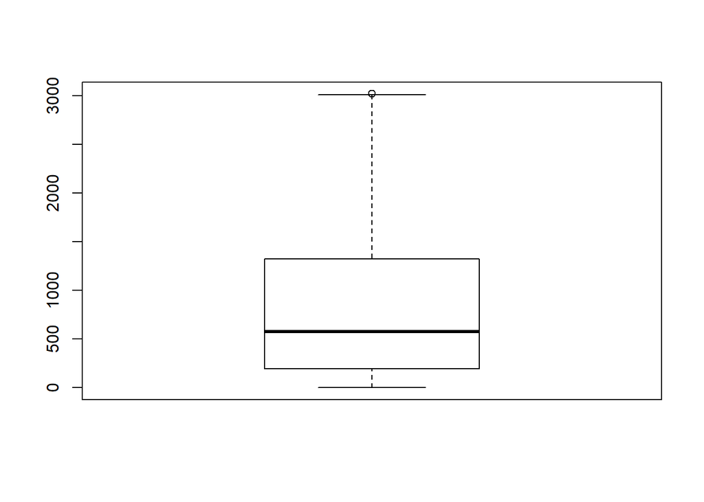

```r
outlier <- boxplot.stats(test$fandf.total.spend)$out
#min(test$fandf.total.spend)
test$fandf.total.spend[test$fandf.total.spend >= min(outlier)] <- min(outlier)
boxplot(test$fandf.total.spend)
```

From `petrol.total.spend`

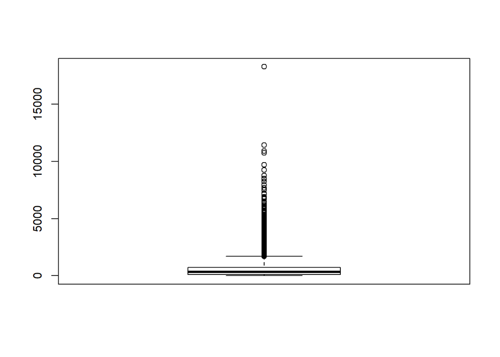

```r
boxplot(test$petrol.total.spend)
```

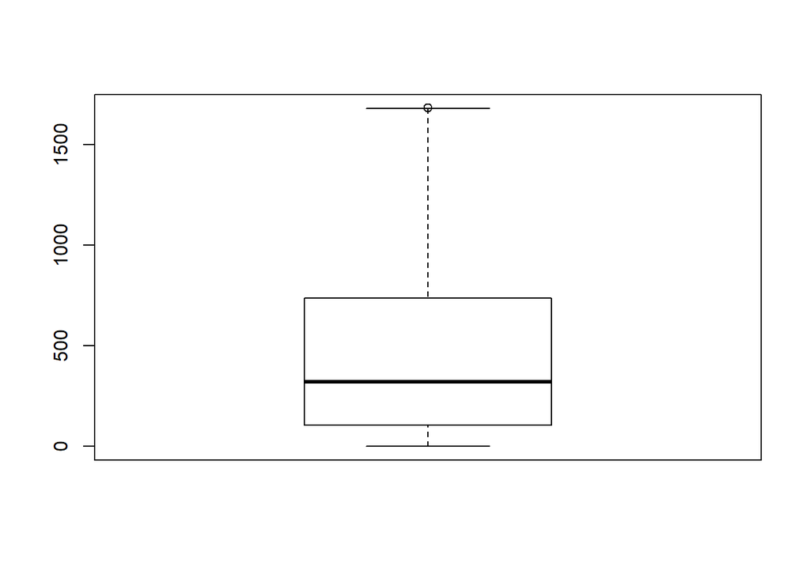

```r
outlier <- boxplot.stats(test$petrol.total.spend)$out
test$petrol.total.spend[test$petrol.total.spend >= min(outlier)] <- min(outlier)
boxplot(test$petrol.total.spend)
```

From `direct.total.spend`

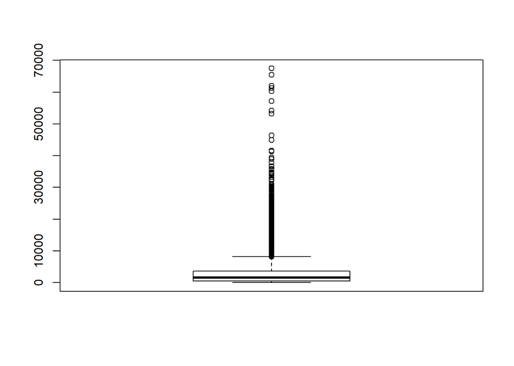

```r
boxplot(test$direct.total.spend)
```

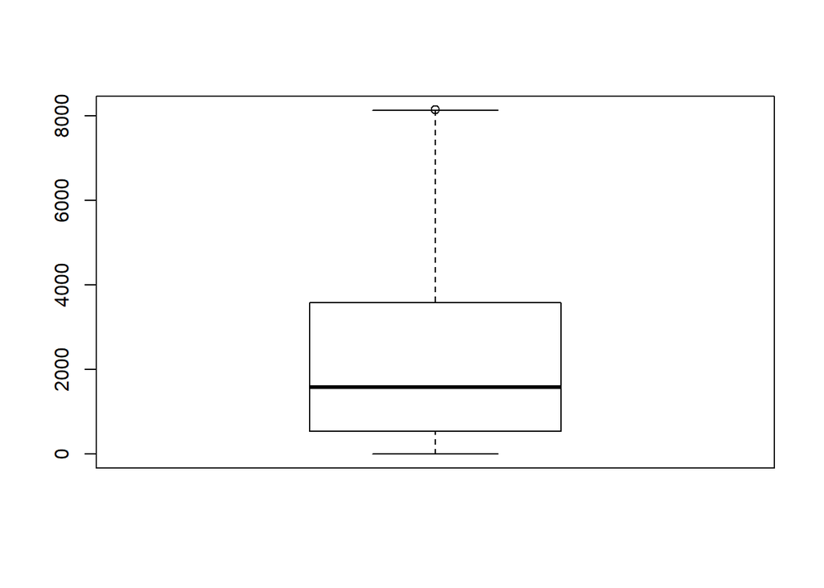

```r
outlier <- boxplot.stats(test$direct.total.spend)$out
#min(test$direct.total.spend)
test$direct.total.spend[test$direct.total.spend >= min(outlier)] <- min(outlier)
boxplot(test$direct.total.spend)
```

```r
#hist(test$direct.total.spend)
#test$direct.total.spend<-log(test$direct.total.spend)
```

We will be using the xgboost model built for prediction

```r
sparse_test<-sparse.model.matrix(~.-1-customer.id-county,data = test)

dtest2<-xgb.DMatrix(data=sparse_test)
pred_test_xgb <- predict(model_xgb,newdata = dtest2)
```

### Calculating `LogLoss`.

We will be calculating logloss for the prediction of clicking on `content1`

```r
# Read the true values as 'labels'
# labels = read.csv(file_name)
#You will have to passthe true value as `labels`
#logloss = LogLoss(y_pred = pred_test_xgb,y_true = labels)
#logloss
```